# PA1_template.rmd

## Loading and preprocessing the data

load packages

```r
library(readr)
library(ggplot2)
library(dplyr, warn.conflicts = FALSE)
```

read the data specifying the column types as numeric, Date, numeric

```r
data <- read_csv("./activity.csv", col_types = "nDn")
```

## What is mean total number of steps taken per day?

calculate the total number of steps per day and plot as a histogram

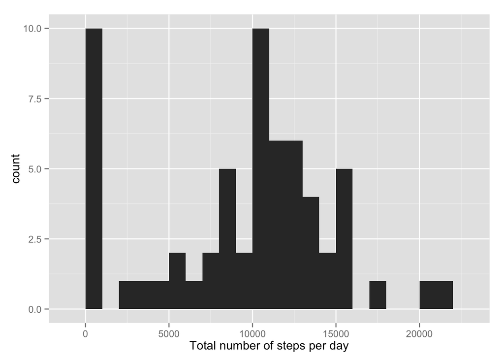

```r
stepsPerDay <- summarize(group_by(data, date), total = sum(steps, na.rm=TRUE))
qplot(stepsPerDay$total, data = stepsPerDay, binwidth = 1000, xlab = "Total number of steps per day")
```

calculated the mean and median number of steps per day and plot

```
## Warning: Removed 2 rows containing missing values (geom_path).
```

```
## Warning: Removed 2 rows containing missing values (geom_path).
```

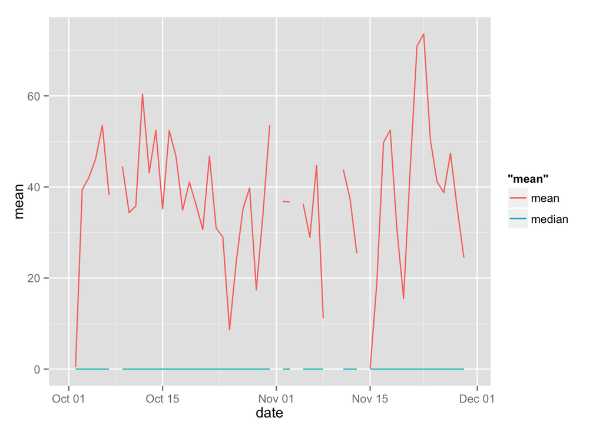

```r
meanAndMedian <- summarize(group_by(data, date),
                           mean = mean(steps, na.rm=TRUE),
                           median = median(steps, na.rm=TRUE))
ggplot(meanAndMedian, aes(date)) +
    geom_line(aes(y = mean, colour = "mean")) +
    geom_line(aes(y = median, colour = "median"))
```

Something looks wrong here as the median is 0 for all days and we got warnings for missing values

## What is the average daily activity pattern?

Plot the average steps by interval

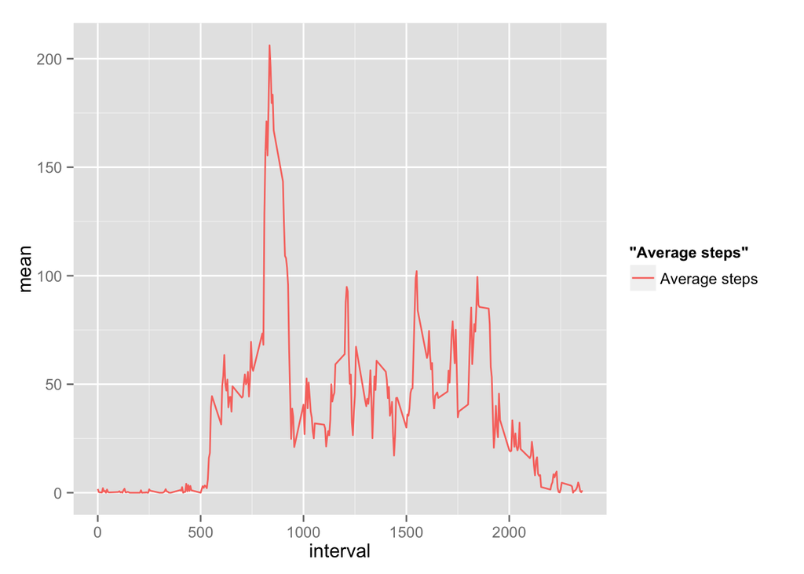

```r
meanByInterval <- summarize(group_by(data, interval),
                           mean = mean(steps, na.rm=TRUE))
ggplot(meanByInterval, aes(interval)) +
    geom_line(aes(y = mean, colour = "Average steps"))
```

08:35 has the highest average number of steps

```r
meanByInterval[which(meanByInterval$mean == max(meanByInterval$mean)),]
```

```
## Source: local data frame [1 x 2]
##
##   interval     mean
##      (dbl)    (dbl)
## 1      835 206.1698
```

## Imputing missing values

there are 2304 missing values in the steps column

```r
summary(data)
```

```
##      steps             date               interval
##  Min.   :  0.00   Min.   :2012-10-01   Min.   :   0.0
##  1st Qu.:  0.00   1st Qu.:2012-10-16   1st Qu.: 588.8
##  Median :  0.00   Median :2012-10-31   Median :1177.5
##  Mean   : 37.38   Mean   :2012-10-31   Mean   :1177.5
##  3rd Qu.: 12.00   3rd Qu.:2012-11-15   3rd Qu.:1766.2
##  Max.   :806.00   Max.   :2012-11-30   Max.   :2355.0
##  NA's   :2304
```

Now let’s try to fill in missing values with the average step for that internval

```r
inputed.data <- left_join(data, meanByInterval, by = "interval")
inputed.data$steps[is.na(inputed.data$steps)] <- inputed.data$mean[is.na(inputed.data$steps)]
```

Now plot the histogram of total number of steps taken each day

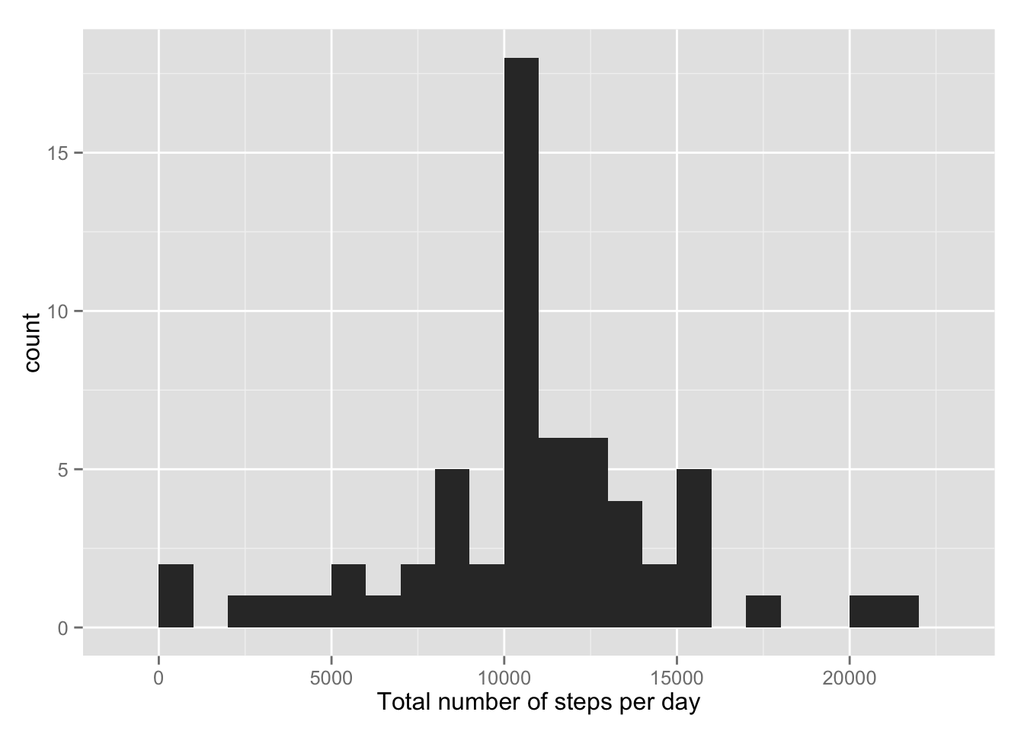

```r
stepsPerDay <- summarize(group_by(inputed.data, date), total = sum(steps, na.rm=TRUE))
qplot(stepsPerDay$total, data = stepsPerDay, binwidth = 1000, xlab = "Total number of steps per day")
```

We see after imputation, that we don’t have as many days with 0 steps. Now let’s look at the mean and median steps per day with imputed data

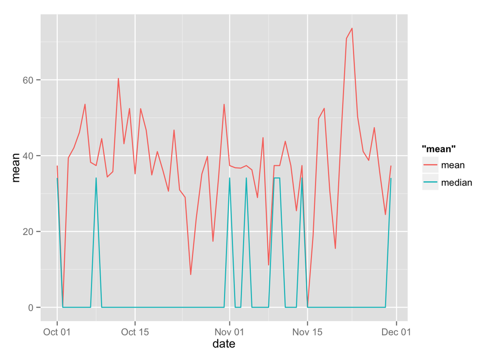

```r
meanAndMedian <- summarize(group_by(inputed.data, date),
                           mean = mean(steps, na.rm=TRUE),
                           median = median(steps, na.rm=TRUE))
ggplot(meanAndMedian, aes(date)) +
    geom_line(aes(y = mean, colour = "mean")) +
    geom_line(aes(y = median, colour = "median"))
```

After imputation, the graph no longer has breaks, but there are still many days with 0 median

## Are there differences in activity patterns between weekdays and weekends?

Let’s create a column called group and use that find the average number of steps taken broken out weekday or weekend

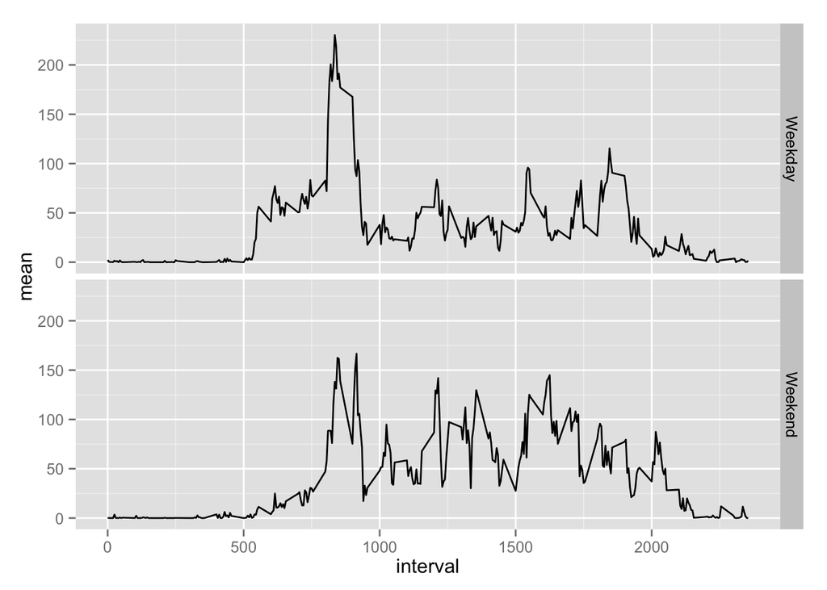

```r
inputed.data$day <- weekdays(inputed.data$date)
inputed.data$group <- ifelse(inputed.data$day %in% c("Saturday", "Sunday"), "Weekend","Weekday")
meanByInterval <- summarize(group_by(inputed.data, interval, group),
                           mean = mean(steps, na.rm=TRUE))
qplot(interval, mean, data = meanByInterval, facets = group~., geom = "line")
```